# Part 2 - ASA Short Course Second-generation p-values (Half-Day)

# Introduction

- Jeffrey D. Blume, PhD
  - School of Data Science, University of Virginia
- Megan H. Murray, PhD
  - Department of Biostatistics, Vanderbilt University

Resources:

- GitHub with Slides and Code: www.github.com/murraymegan/SGPV-ASA-Short-Course
- RStudio Desktop: www.rstudio.com/products/rstudio/download
- Interrupt or use Zoom chat for questions!

# 1 SGPV R Package

There are 2 ways to install `sgpv` package.

- CRAN: `install.packages("sgpv")`
- GitHub: `devtools::install_github("weltybiostat/sgpv")`

```r
#GitHub
install.packages("devtools")
devtools::install_github("weltybiostat/sgpv")

#CRAN
install.packages("sgpv")
```

Functions Included:

- `sgpvalue()`
  - This function computes the second-generation p-value (SGPV) and its associated delta gaps, as introduced in Blume et al. (2018).
- `sgpower()`
  - Calculate power and type I error values from significance testing based on second-generation p-values as the inferential metric.
- `plotsgpv()`
  - This function displays user supplied interval estimates (support intervals, confidence intervals, credible intervals, etc.) according to its associated second-generation p-value ranking.
- `plotman()`
  - This function displays a modified Manhattan-style plot colored according to second-generation p-value status.
- `fdrisk()`
  - This function computes the false discovery risk (sometimes called the “empirical bayes FDR”) for a second-generation p-value of 0, or the false confirmation risk for a second-generation p-value of 1.

# 2 Part 2

## 2.1 Statistical Properties

3 inference outcomes:

- Data are consistent with null $p_\delta=1$
- Data are consistent with alternative $p_\delta=0$
- Data are inconclusive $0<p_\delta<1$

2 underlying truths:

- Null is true
- Alternative is true

### 2.1.1 CIs can miss (bummer)

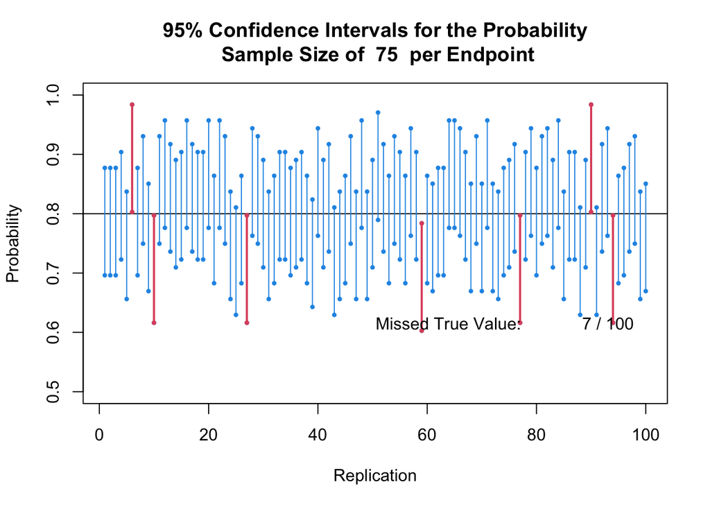

```r
cidemo = function(rep=100,
                  mu=0.8,
                  n=200,
                  alpha=0.05,
                  ylb="Probability",
                  ltype=1,
                  lcol=4,
                  ltype1=1,
                  lwd1=2,
                  lcol1=2,
                  plotset=F,
                  hilim=1,
                  lolim=0.5,
                  bcol="lemonchiffon2",
                  xleg=45,
                  yleg=0.65,
                  idz.lo=0.75,
                  idz.hi=0.85,
                  zone=TRUE){

  cints=matrix(0,3,rep)

  cints[1,]=seq(1,rep,1)
  sigma=sqrt(mu*(1-mu))

  for (i in 1:rep) {

  dat=rbinom(n,1,prob=mu)

  ## Standard normal quantile
  za=abs(qnorm(alpha/2))

  ## upper CI limit
  cints[2,i]=mean(dat)+za*sigma/sqrt(n)

  ## Lower CI limit
  cints[3,i]=mean(dat)-za*sigma/sqrt(n)
  }

  if (plotset==T){
    lolim=mu-5*sigma/sqrt(n)
    hilim=mu+5*sigma/sqrt(n)
  }

  if (sigma!=1){
    plot(cints[1,],cints[2,],ylim=c(lolim,hilim),type="n",
    main=paste("95% Confidence Intervals for the Probability\n Sample Size of ",n," per Endpoint"),
    ylab=ylb,xlab="Replication")
    }

  if (sigma==1){
    plot(cints[1,],cints[2,],ylim=c(lolim,hilim),type="n",
    main=paste("95% Confidence Intervals on the Standardized Effect Size \n Sample Size of ",n," per Endpoint"),
    ylab="Standardized Effect Size (X/sigma units)",xlab="Endpoint Identification Number")
    }

  if (zone==TRUE) {
    polygon(c(0,rep,rep,0),c(idz.hi,idz.hi,idz.lo,idz.lo),density=200,col=bcol)
  }

  abline(h=mu)
  points(cints[1,],cints[2,],cex=0.6,pch=16,col=lcol)
  points(cints[1,],cints[3,],cex=0.6,pch=16,col=lcol)
  segments(cints[1,], cints[2,], cints[1,], cints[3,],lty=ltype,col=lcol)

  ct=0
  ct2=0
  for (i in 1:rep) {

    if (cints[2,i]<mu | cints[3,i]>mu){
        segments(cints[1,i], cints[2,i],
                 cints[1,i],cints[3,i],
                 lty=ltype1,col=lcol1,lwd=lwd1)
        points(cints[1,i],cints[2,i],cex=0.6,pch=16,col=lcol1)
        points(cints[1,i],cints[3,i],cex=0.6,pch=16,col=lcol1)
        ct=ct+1}

    if (cints[2,i]<idz.lo | cints[3,i]>idz.hi){
      ct2=ct2+1
    }
  }

  if (rep>100){
    abline(h=idz.hi,col=bcol,lty=2,lwd=1.5)
    abline(h=idz.lo,col=bcol,lty=2,lwd=1.5)
  }

  ## prob of missing indifference zone
  ## P(CI upper limit<idz.lo) +P(CI lower limit>idz.hi)
  miss.idz=pnorm(-za+idz.lo*sqrt(n)/sigma)+pnorm(-za-idz.hi*sqrt(n)/sigma)

  if (zone==TRUE){
    legend(xleg,yleg,bty="n",
    c(paste("Missed True Value:             ",ct," / ",rep,sep=""),
    paste("Missed Indifference Zone:   ",ct2," / ",rep,sep="")))
  }

  if (zone!=TRUE){
    legend(xleg,yleg,bty="n",
    c(paste("Missed True Value:             ",
            ct," / ",rep,sep="")))
  }

}

set.seed(999)

cidemo(n=75,zone=FALSE)
```

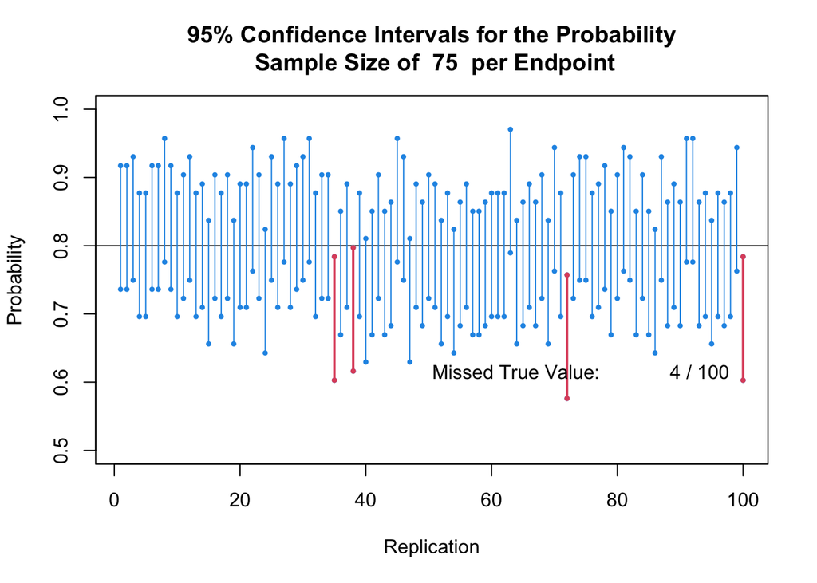

```r
cidemo(n=75,zone=FALSE)
```

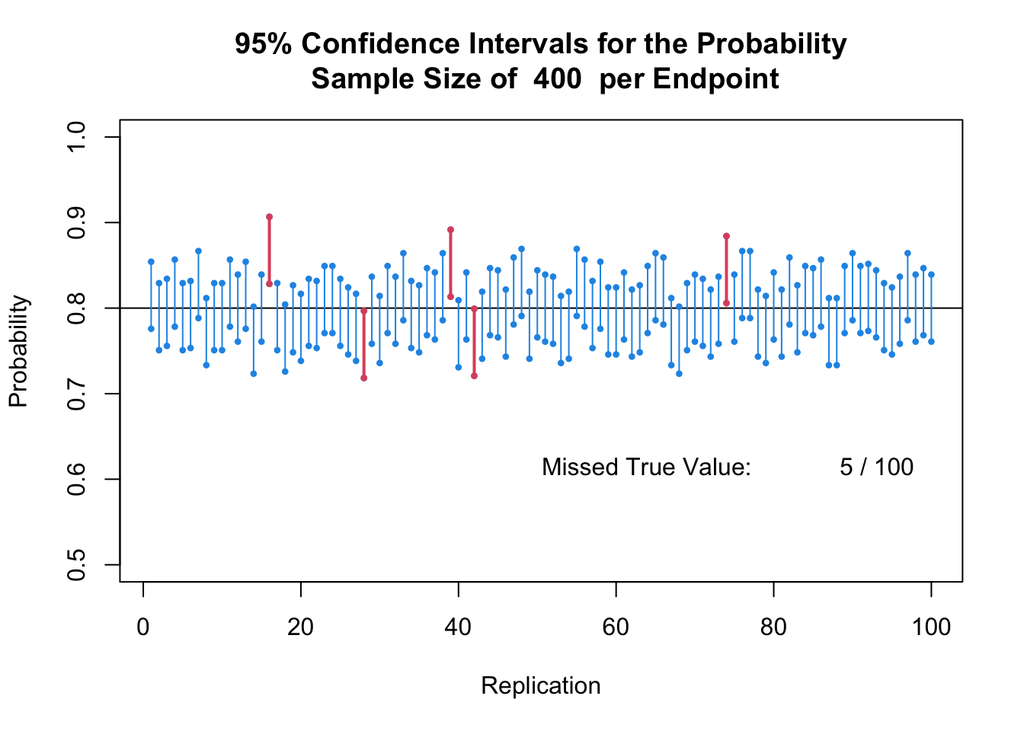

```r
cidemo(n=400,zone=FALSE)
```

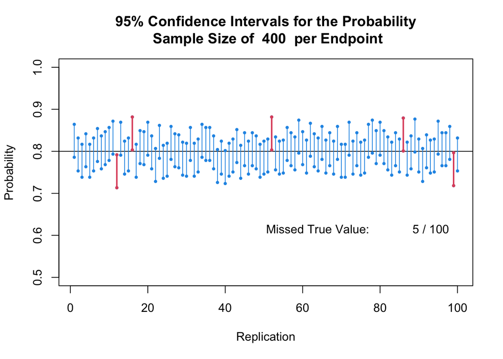

```r
cidemo(n=400,zone=FALSE)
```

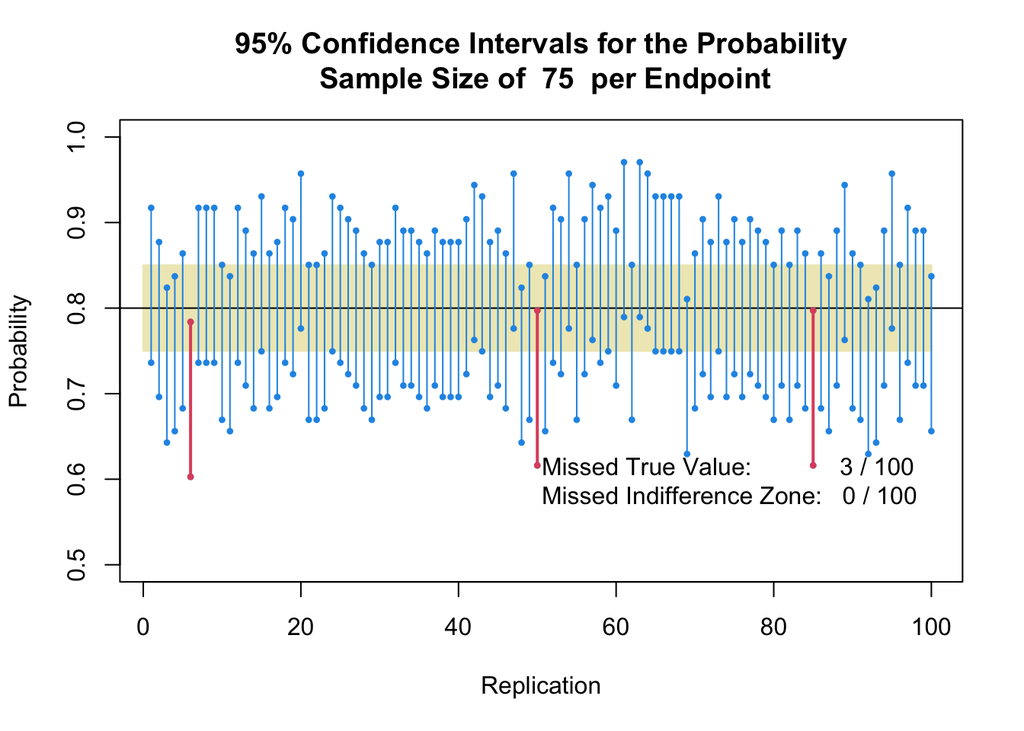

```r
cidemo(n=75)
```

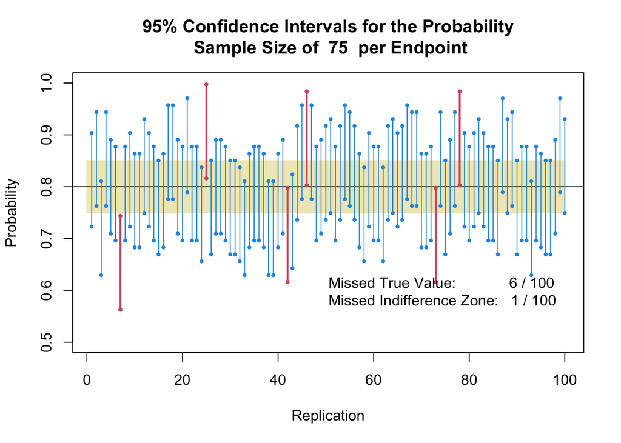

```r
cidemo(n=75)
```

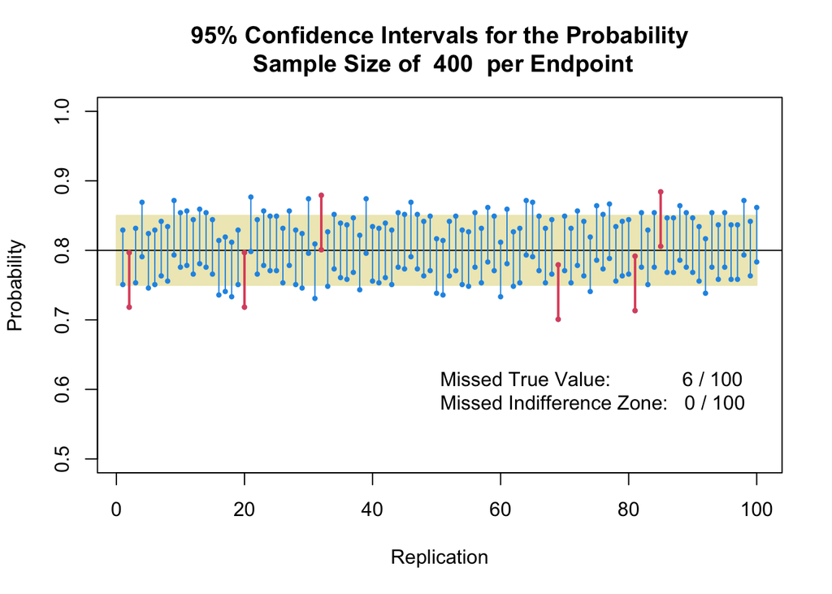

```r
cidemo(n=400)
```

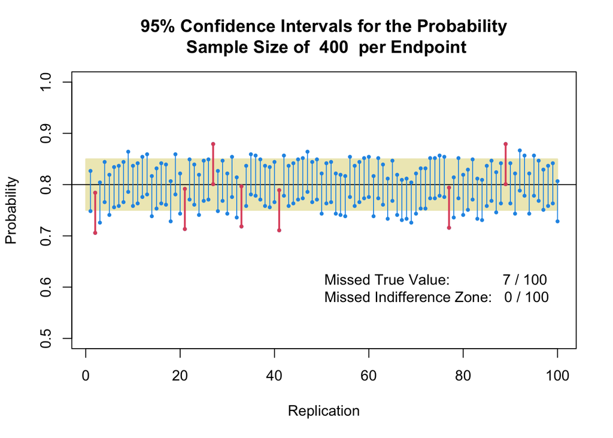

```r
cidemo(n=400)
```

```r
prob.alt.sg = function(n, null.delta,
                    theta0=0,
                    theta=0,
                    V=1,
                    alpha=0.05){
  results = rep(NA, length(n))

  results = pnorm(sqrt(n)*(theta0-null.delta)/sqrt(V)-sqrt(n)*theta/sqrt(V)-qnorm(1-alpha/2))+
    pnorm(-1*sqrt(n)*(theta0+null.delta)/sqrt(V)+sqrt(n)*theta/sqrt(V)-qnorm(1-alpha/2))

  results
}
```

### Errors and Plots

```r
prob.null.sg = function(n,
                        null.delta,
                     theta0=0,
                     theta=0,
                     V=1,
                     alpha=0.05){
  results = rep(NA, length(n))

  if(length(null.delta)>1){
    con.large = which(null.delta>(qnorm(1-alpha/2)*sqrt(V)/sqrt(n)))
    con.small = which(null.delta<=(qnorm(1-alpha/2)*sqrt(V)/sqrt(n)))

    results[con.small] = rep(0, length(con.small))
    results[con.large] =
      pnorm(sqrt(n[con.large])*theta0+sqrt(n[con.large])*null.delta[con.large]/sqrt(V)-sqrt(n[con.large])*theta/sqrt(V)-qnorm(1-alpha/2))-
      pnorm(sqrt(n[con.large])*theta0-sqrt(n[con.large])*null.delta[con.large]/sqrt(V)-sqrt(n[con.large])*theta/sqrt(V)+qnorm(1-alpha/2))
  }else if(null.delta>(qnorm(1-alpha/2)*sqrt(V)/sqrt(n))){
    results =
      pnorm(sqrt(n)*theta0+sqrt(n)*null.delta/sqrt(V)-sqrt(n)*theta/sqrt(V)-qnorm(1-alpha/2))-
      pnorm(sqrt(n)*theta0-sqrt(n)*null.delta/sqrt(V)-sqrt(n)*theta/sqrt(V)+qnorm(1-alpha/2))
  }else{
    results = rep(0, length(theta))
  }
  results
}
```

```r
prob.incon.sg = function(n, null.delta,
                    theta0=0,
                    theta=0,
                    V=1,
                    alpha=0.05){
  results = rep(NA, length(n))

  con.large = which(null.delta>(qnorm(1-alpha/2)*sqrt(V)/sqrt(n)))
  con.small = which(null.delta<=(qnorm(1-alpha/2)*sqrt(V)/sqrt(n)))

  results = 1-(prob.alt.sg(n, null.delta,
                        theta0,
                        theta,
                        V,
                        alpha)+
                 prob.null.sg(n, null.delta,
                           theta0,
                           theta,
                           V,
                           alpha))

  results
}
```

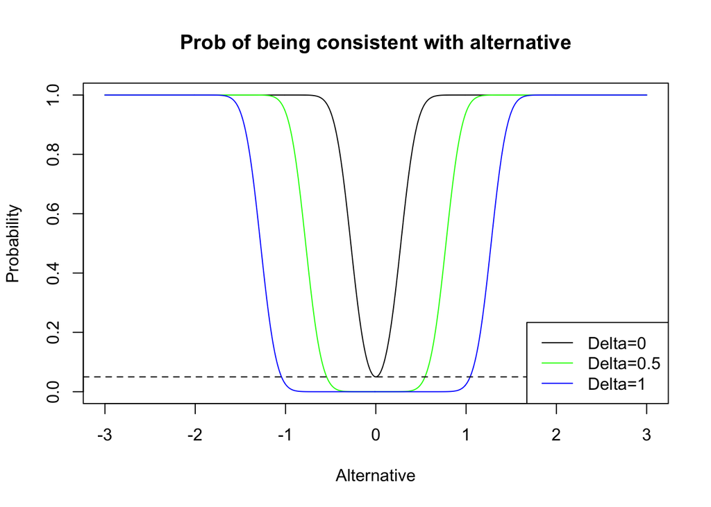

```r
theta.1 = seq(-3,3,by=0.01)

plot(theta.1, prob.alt.sg(n=50,
            null.delta = 0,
            theta=theta.1), type="l",
     ylim=c(0,1),
     xlab="Alternative",
     ylab="Probability",
     main="Prob of being consistent with alternative")
lines(theta.1, prob.alt.sg(n=50,
            null.delta = 0.5,
            theta=theta.1),
      col="green")
lines(theta.1, prob.alt.sg(n=50,
            null.delta = 1,
            theta=theta.1),
      col="blue")
abline(h=0.05, lty=2)
legend("bottomright",
       legend=c("Delta=0", "Delta=0.5", "Delta=1"),
       col=c("black", "green","blue"), lty=1)
```

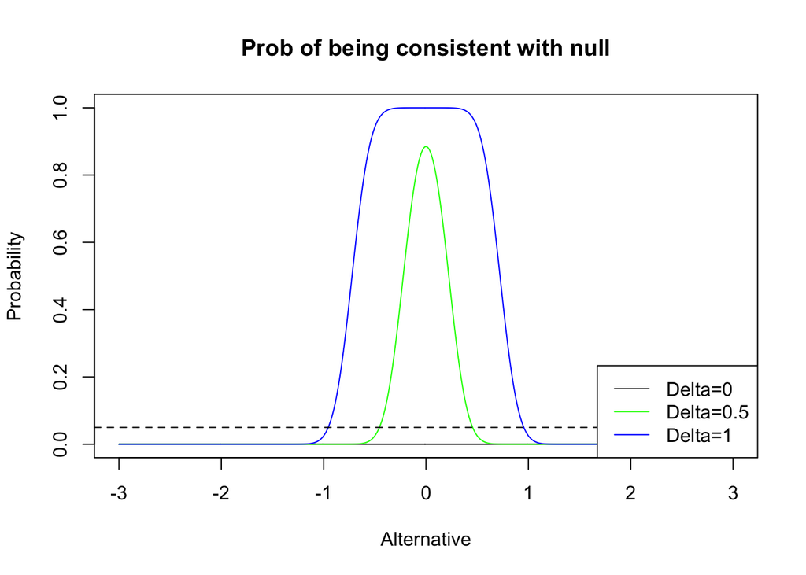

```r
theta.1 = seq(-3,3,by=0.01)

plot(theta.1, prob.null.sg(n=50,
            null.delta = 0,
            theta=theta.1), type="l",
     ylim=c(0,1),
     xlab="Alternative",
     ylab="Probability",
     main="Prob of being consistent with null")
lines(theta.1, prob.null.sg(n=50,
            null.delta = 0.5,
            theta=theta.1),
      col="green")
lines(theta.1, prob.null.sg(n=50,
            null.delta = 1,
            theta=theta.1),
      col="blue")
abline(h=0.05, lty=2)
legend("bottomright",
       legend=c("Delta=0", "Delta=0.5", "Delta=1"),
       col=c("black", "green","blue"), lty=1)
```

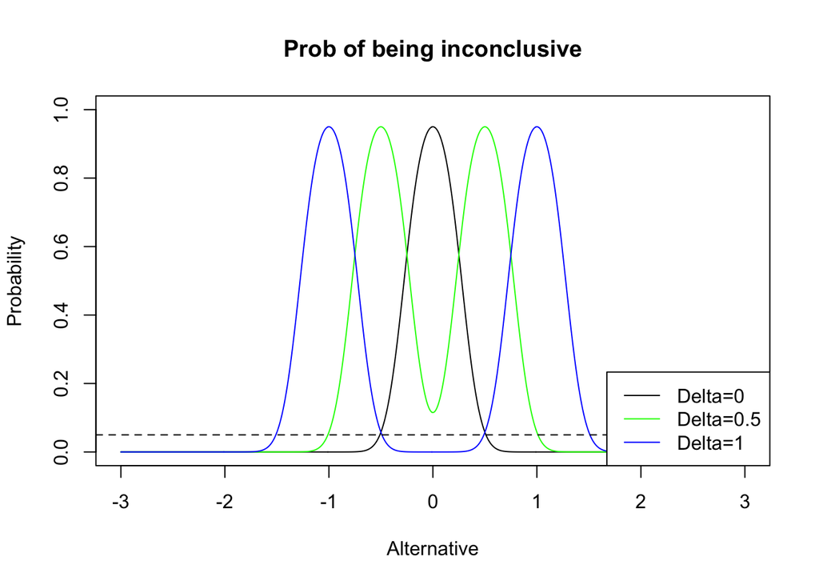

```r
theta.1 = seq(-3,3,by=0.01)

plot(theta.1, prob.incon.sg(n=50,
            null.delta = 0,
            theta=theta.1), type="l",
     ylim=c(0,1),
     xlab="Alternative",
     ylab="Probability",
     main="Prob of being inconclusive")
lines(theta.1, prob.incon.sg(n=50,
            null.delta = 0.5,
            theta=theta.1),
      col="green")
lines(theta.1, prob.incon.sg(n=50,
            null.delta = 1,
            theta=theta.1),
      col="blue")
abline(h=0.05, lty=2)
legend("bottomright",
       legend=c("Delta=0", "Delta=0.5", "Delta=1"),
       col=c("black", "green","blue"), lty=1)
```

## 2.2 SGPV False Discovery Risk

- False Discovery Rate (FDR)
  - SGPV = 0
- False Confirmation Rate (FCR)
  - SGPV = 1
- `sgpv::fdrisk()`
  - This function computes the false discovery risk (sometimes called the “empirical bayes FDR”) for a second-generation p-value of 0, or the false confirmation risk for a second-generation p-value of 1.

```r
###### FDR rates
# false discovery risk with 95% confidence level
fdrisk(sgpval = 0,
       null.lo = log(1/1.1),
       null.hi = log(1.1),
       std.err = 0.8,
       null.weights = 'Uniform',
       null.space = c(log(1/1.1), log(1.1)),
       alt.weights = 'Uniform',
       alt.space = 2 + c(-1,1)*qnorm(1-0.05/2)*0.8,
       interval.type = 'confidence',
       interval.level = 0.05)
```

```
## [1] 0.05949861
```

```r
## with truncated normal weighting distribution
fdrisk(sgpval = 0,
       null.lo = log(1/1.1),
       null.hi = log(1.1),
       std.err = 0.8,
       null.weights = 'Point',
       null.space = 0,
       alt.weights = 'TruncNormal',
       alt.space = 2 + c(-1,1)*qnorm(1-0.041/2)*0.8,
       interval.type = 'likelihood',  interval.level = 1/8)
```

```
## [1] 0.04902575
```

```r
# false discovery risk with LSI and wider null hypothesis
fdrisk(sgpval = 0,
       null.lo = log(1/1.5),
       null.hi = log(1.5),
       std.err = 0.8,
       null.weights = 'Point',
       null.space = 0,
       alt.weights = 'Uniform',
       alt.space = 2.5 + c(-1,1)*qnorm(1-0.041/2)*0.8,
       interval.type = 'likelihood',
       interval.level = 1/8)
```

```
## [1] 0.01688343
```

```r
# false confirmation risk example
fdrisk(sgpval = 1,
       null.lo = log(1/1.5),
       null.hi = log(1.5),
       std.err = 0.15,
       null.weights = 'Uniform',
       null.space = 0.01 + c(-1,1)*qnorm(1-0.041/2)*0.15,
       alt.weights = 'Uniform',
       alt.space = c(log(1.5), 1.25*log(1.5)),
       interval.type = 'likelihood',
       interval.level = 1/8)
```

```
## [1] 0.03059522
```

```r
###
##
#
```

False Discovery and Confirmation Rates

```r
power.pv=function(n=20,sd=1,alpha=0.05,mu.l=-3,mu.u=3,delta=0.3,mu.0=0,r=1){

  ## Computes power when delta is zero and non-zero
  ## Inputs:
  ## n is sample size
  ## indifference zone is: mu.0 +/- delta
  ## alternative space is: mu in [mu.l, mu.u]
  ## data ~ N(mu,sd)
  ## r = P(H1)/P(H0) for simple H1 and H0

  mu=seq(mu.l,mu.u,0.01)

  ## Power (null is mu.0 ; alt is mu)
  pow1.d=pnorm(-sqrt(n)*(delta-(mu.0-mu))/sd-qnorm(1-alpha/2))
  pow2.d=pnorm(-sqrt(n)*(delta+(mu.0-mu))/sd-qnorm(1-alpha/2))
  power.d=pow1.d+pow2.d

  ## Power without indifference zone (delta=0)
  pow1.0=pnorm(-sqrt(n)*(0-(mu.0-mu))/sd-qnorm(1-alpha/2))
  pow2.0=pnorm(-sqrt(n)*(0+(mu.0-mu))/sd-qnorm(1-alpha/2))
  power.0=pow1.0+pow2.0

  ## Type I error (null is mu.0 ; alt is mu.0)
  alpha.d=2*pnorm(-sqrt(n)*(delta)/sd-qnorm(1-alpha/2))

  ## Type I error without indifference zone (delta=0)
  alpha.0=2*pnorm(-sqrt(n)*(0)/sd-qnorm(1-alpha/2))

  ## P(sgpv=1|H0) not quite alpha b/c rules out inconclusive
  gam1.0=pnorm(sqrt(n)*(delta)/sd-qnorm(1-alpha/2))
  gam2.0=pnorm(sqrt(n)*(-delta)/sd+qnorm(1-alpha/2))
  gam.0=(gam1.0-gam2.0)*(delta>qnorm(1-alpha/2)*sd/sqrt(n))

  ##
  gam1.a=pnorm(sqrt(n)*(delta+mu.0-mu)/sd-qnorm(1-alpha/2))
  gam2.a=pnorm(sqrt(n)*(mu.0-delta-mu)/sd+qnorm(1-alpha/2))
  gam.a=(gam1.a-gam2.a)*(delta>qnorm(1-alpha/2)*sd/sqrt(n))

  ## False discovery rates (fdr1=FDR ; fdr0=FNDR)
  fdr.d = 1 / (1 + power.d/alpha.d * r)
  fndr.0 = 1 / (1 + (1-alpha.0)/(1-power.0) * (1/r))

  fdr.0 = 1 / (1 + power.0/alpha.0 * r)
  fndr.d = 1 / (1 + gam.0/gam.a * (1/r))

  ret=cbind(mu,alpha.d,power.d,fdr.d,fndr.d,
                alpha.0,power.0,fdr.0,fndr.0,gam.0,gam.a)
  colnames(ret)=c('mu','alpha.d','power.d','fdr.d','fndr.d',
                        'alpha.0','power.0','fdr.0','fndr.0',
                            'gam.0','gam.a')
  ret
}
```

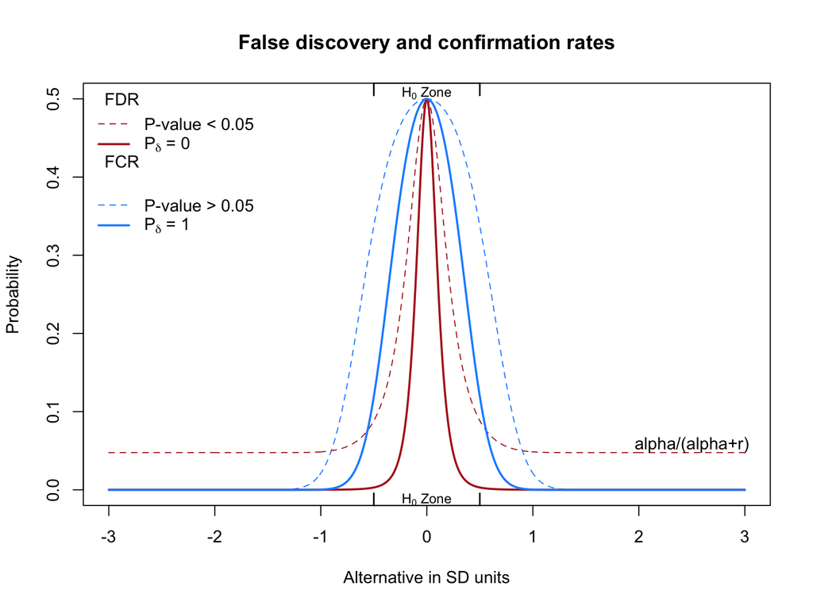

```r
par(mfrow=c(1,1))
prev.ratio=1
set.delta=0.5
set.n=16

all=power.pv(delta=set.delta,n=set.n,r=prev.ratio,alpha=0.05)

plot(all[,'mu'],all[,'fdr.0'],type="n",ylab="Probability",xlab="Alternative in SD units",
     ylim=c(0,prev.ratio/(prev.ratio+1)),xlim=c(-3,3))
title(main="False discovery and confirmation rates")

lines(all[,'mu'],all[,'fdr.0'],col="firebrick",lwd=1,lty=2)
lines(all[,'mu'],all[,'fndr.0'],col="dodgerblue",lwd=1,lty=2)

lines(all[,'mu'],all[,'fdr.d'],col="firebrick",lwd=2)
lines(all[,'mu'],all[,'fndr.d'],col="dodgerblue",lwd=2)

legend("topleft",c("",
                   expression(paste("P-value < ",0.05,sep="")),
                   expression(paste(P[delta]," = 0",sep="")),
                   "", "",
                   expression(paste("P-value > ",0.05,sep="")),
                   expression(paste(P[delta]," = 1",sep=""))),
       col=c("","firebrick","firebrick","","",
             "dodgerblue","dodgerblue"),
       lty=c(NA,2,1,NA,NA,2,1),lwd=c(NA,1,2,NA,NA,1,2),bty="n")

text(-2.875,0.5,"FDR")
text(-2.875,0.42,"FCR")

axis(side = 1, at = c(-set.delta,set.delta),cex.axis=0.8,col.ticks="black",lwd.ticks=1.5,tcl=0.6,labels=FALSE)
axis(side = 3, at = c(-set.delta,set.delta),cex.axis=0.8,col.ticks="black",lwd.ticks=1.5,tcl=0.6,labels=FALSE)

text(0,-0.0125,expression(paste(H[0]," Zone",sep="")),cex=0.8)
text(0,prev.ratio/(prev.ratio+1)*1.015,expression(paste(H[0]," Zone",sep="")),cex=0.8)

text(2.5,0.05/(prev.ratio+0.05)+.01,"alpha/(alpha+r)")
```

## 2.3 Equivalence tests: TOST

- Establish bioequivalence between data and an established range
- Example: A pharmaceutical company tests for drug approval by comparing new drug’s performance to an approved drug’s performance
- Tests are ordinary, one-sided, α-level t-tests
- Flips the null and alternative hypotheses

```r
n=6
dat = rnorm(n, 0, 1)
a = t.test(dat)$conf.int[1]
b =  t.test(dat)$conf.int[2]

x_bar = mean(dat)
S = sd(dat)
Z = (b-x_bar)/(S/sqrt(n))

theta_p = 0.5*0.75
theta_m = -0.5*0.75

out_TOST = tsum_TOST(m1=x_bar,
            mu=0,
            sd1=S,
            n1=n,
            low_eqbound=theta_m,
            high_eqbound=theta_p,
            alpha=0.05,
            eqbound_type = "raw")

out_TOST$TOST
```

```
##                     t        SE df   p.value
## t-test      0.1645490 0.4629848  5 0.8757443
## TOST Lower  0.9745108 0.4629848  5 0.1872798
## TOST Upper -0.6454127 0.4629848  5 0.2735524
```

```r
max(out_TOST$TOST$p.value[2], out_TOST$TOST$p.value[3])
```

```
## [1] 0.2735524
```

```r
out_sgpv = sgpvalue(est.lo=a,
                       est.hi=b,
                       null.lo=theta_m,
                       null.hi=theta_p)

out_sgpv
```

```
## $p.delta
## [1] 0.5
##
## $delta.gap
## [1] NA
```

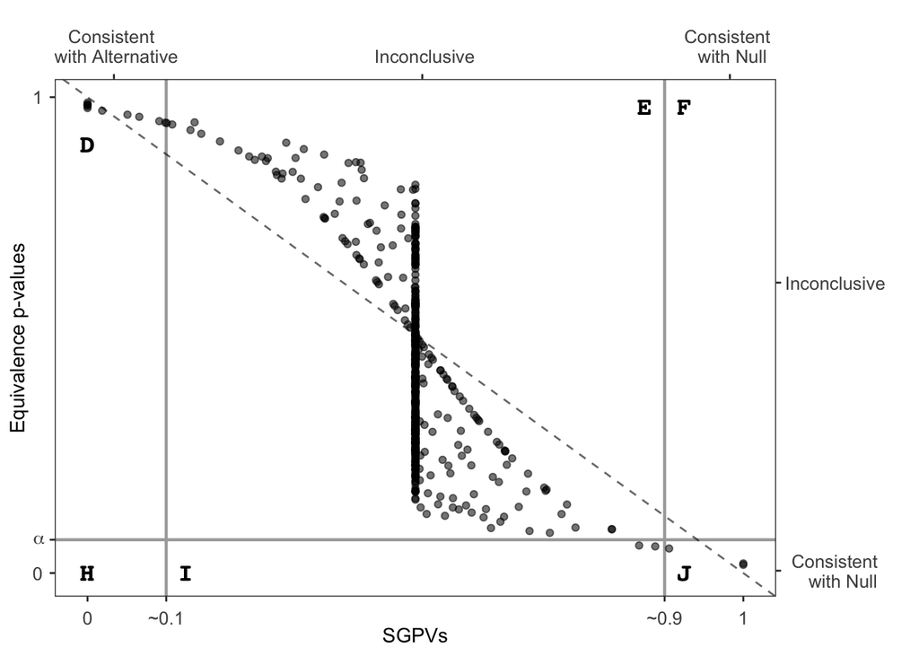

```r
set.seed(999)
iter=500
n=6
results = as.data.frame(matrix(ncol=3, nrow=iter))
colnames(results) = c("sgpv", "tost", "Case")
half.case = NULL
half.case2 = NULL

for(i in 1:iter){
  dat = rnorm(n, 0, 1)
  a = t.test(dat)$conf.int[1]
  b =  t.test(dat)$conf.int[2]
  x_bar = mean(dat)
  S = sd(dat)
  Z = (b-x_bar)/(S/sqrt(n))

  theta_p = 0.5*0.75
  theta_m = -0.5*0.75

  out_TOST = tsum_TOST(m1=x_bar,
            mu=0,
            sd1=S,
            n1=n,
            low_eqbound=theta_m,
            high_eqbound=theta_p,
            alpha=0.05,
            eqbound_type = "raw")

  out_sgpv = sgpvalue(est.lo=a,
                       est.hi=b,
                       null.lo=theta_m,
                       null.hi=theta_p)$p.delta

  results[i,1] = out_sgpv
  results[i,2] = pmax(out_TOST$TOST$p.value[2],out_TOST$TOST$p.value[3])

  if(theta_m<a & theta_p>a & theta_p<b){
    # Case 4 some overlap
    results[i,3] = "\n Case 4: \nPartial Overlap"
  }else if(theta_m<b & theta_p>b & theta_m>a){
    # Case 3 some overlap
    results[i,3] = "\n Case 3: \nPartial Overlap"
  }else if(theta_m>b | theta_p<a){
    # Case 1 no overlap
    results[i,3] = "\n Case 1: \nNo Overlap"
  }else if((theta_m>a & theta_p<b)|(theta_m<=a & theta_p>=b)){
    # Case 2 complete overlap
    results[i,3] = "\n Case 2: \nComplete Overlap"
  }
}


library(ggplot2)
scaleFUN <- function(x) sprintf("%.1f", x)

g = ggplot(results, aes(sgpv, tost))+
  xlab("SGPVs") +
  ylab("Equivalence p-values") +
  geom_point(aes(alpha=0.2)) +
  geom_abline(intercept = 1, slope = -1,linetype='dashed', alpha=0.6)+
  xlim(c(0,1))+
  scale_x_continuous(breaks= c( 0,0.120001,0.880001,1),labels=c("0", "~0.1", "~0.9", "1"), minor_breaks = c(0.12,0.88),
                      sec.axis=sec_axis(~./1, name="",breaks= c( 0.04,0.51,0.98), labels=c("Consistent \n with Alternative", "\n Inconclusive", "Consistent \n with Null")))+
  scale_y_continuous(breaks= c(0,0.07,1),  labels=c("0", expression(alpha), "1"),minor_breaks = c(0.070001),
                     sec.axis=sec_axis(~./1, name="", breaks= c(0.005,0.61), labels=c("Consistent \n with Null","Inconclusive")))+
  annotate(geom="text", x=0, y=0.9, label="D",
              size=5,
           family = "Courier-Bold")+
  annotate(geom="text", x=0.85, y=0.98, label="E",
              size=5,
           family = "Courier-Bold")+
  annotate(geom="text", x=0.91, y=0.98, label="F",
              size=5,
           family = "Courier-Bold")+
  annotate(geom="text", x=0, y=0, label="H",
              size=5,
           family = "Courier-Bold")+
  annotate(geom="text", x=0.15, y=0, label="I",
              size=5,
           family = "Courier-Bold")+
  annotate(geom="text", x=0.91, y=0, label="J",
              size=5,
           family = "Courier-Bold")+
  theme_bw()+
  theme(axis.text.y =  element_text(size=10, hjust=-0.5),
        axis.text.y.right =  element_text(size=10, hjust=0.7),
         axis.text.x.top =  element_text(size=10, vjust=2),
        axis.text.x =  element_text(size=10, vjust=-0.5),
        panel.grid.major = element_blank(),
        panel.grid.minor = element_line(size = 0.8,colour="darkgrey"))+
    guides(alpha=FALSE)
g
```

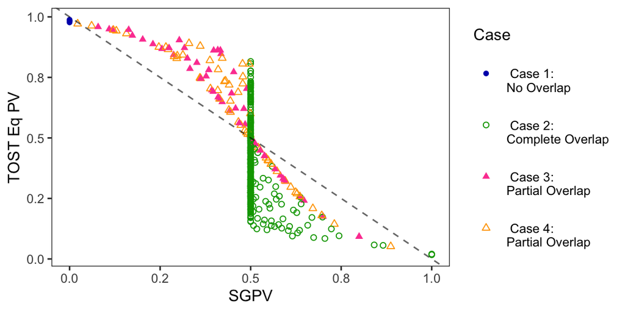

```r
ggplot(results, aes(sgpv, tost, col=Case, pch=Case))+
  geom_point(aes(), cex=1.5) +
  # geom_jitter(width = 0.02, height = 0.02)+
  # ggtitle(paste0("Derived Sample Size= ",n," Iterations= ", iter))+
  xlab("SGPV") +
  ylab("TOST Eq PV") +
  # facet_wrap(~ Case) +
  geom_abline(intercept = 1, slope = -1,linetype='dashed', alpha=0.6)+
  scale_color_manual(values=c("#0000B9",
                              "#00A300",
                              "#FD49A0",
                              "#FFA500",
                              "black"))+
  scale_shape_manual(values=c(16,21,17,24,21))+
    guides(alpha=FALSE)+
  scale_y_continuous(labels=scaleFUN)+
  scale_x_continuous(labels=scaleFUN)+
  guides(color = guide_legend(byrow = TRUE))+
   theme_bw()+
  theme(panel.grid.major = element_blank(),
        panel.grid.minor = element_blank(),
        legend.spacing.y = unit(0.3, 'cm'))
```

## 2.4 Study Planning

Purpose: Evaluate how different techniques of setting the indifference zone effect the SGPV study properties.

What options does a collaborator have when they are uncertain of the indifference zone?

#### Fixed Intervals

```r
n= seq(1,250, by=0.1)
V=1
alpha=0.05

null.delta0 = rep(0.5, length(n))
null.delta1 = rep(0, length(n))
null.delta2 = rep(1.25, length(n))
null.delta3 = rep(1, length(n))
null.delta4 = rep(0.75, length(n))
null.delta5 = rep(0.25, length(n))

ci.bound = qnorm(1-alpha/2)*sqrt(V)/sqrt(n)
```

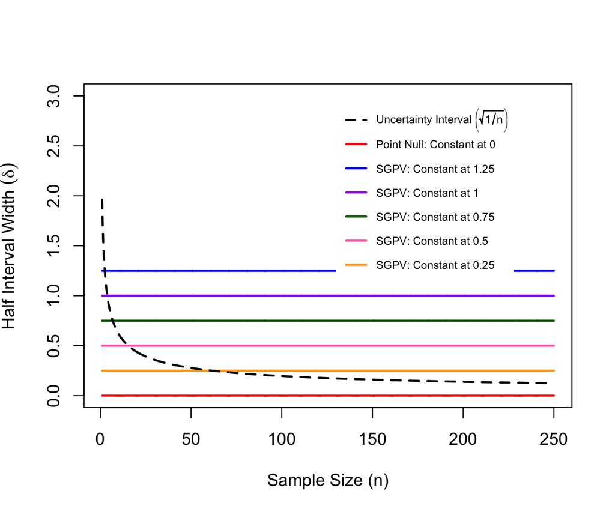

```r
plot(n, null.delta1,
     type="l",
     col="red",
     lwd=2,
     ylim=c(0,3),
     ylab=TeX(r'(Half Interval Width $ (\delta)$)'),
     xlab = "Sample Size (n)",
     main="")
lines(n, null.delta2,
      col="blue",
      lwd=2)
lines(n, null.delta3,
      col="purple",
      lwd=2)
lines(n, null.delta4,
      col="darkgreen",
      lwd=2)
lines(n, null.delta5,
      col="orange",
      lwd=2)
lines(n, null.delta0,
      col="hotpink",
      lwd=2)
lines(n, ci.bound,
      col="black",
      lty=2,
      lwd=2)
# abline(h=0.05, col="black", lty=2)
legend(130,
       3,
        col=c("black",
             "red",
             "blue",
             "purple",
             "darkgreen",
             "hotpink",
             "orange"),
       box.lty=0,
       lty=c(2,
             1,
             1,
             1,
             1,
             1,
             1),
       cex=0.65,
       lwd=2,
       legend=c(TeX(r'(Uncertainty Interval $\left(\sqrt{1/n}\right)$)'),
                "Point Null: Constant at 0",
                "SGPV: Constant at 1.25",
                "SGPV: Constant at 1",
                "SGPV: Constant at 0.75",
                "SGPV: Constant at 0.5",
                "SGPV: Constant at 0.25"))
```

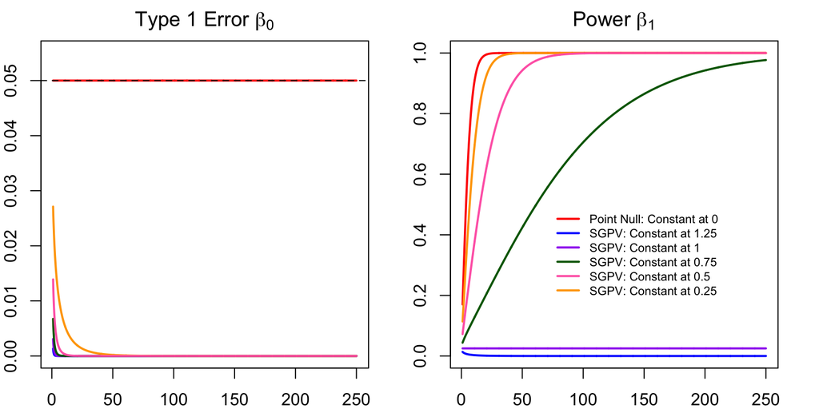

```r
par(mfrow=c(1,2))
par(mar=c(2,2,2,2))

plot(n, prob.alt.sg(n, null.delta1,
                  theta=0),
     type="l",
     col="red",
     lwd=2,
     ylim=c(0,0.055),
     ylab="",
     main=TeX(r'(Type 1 Error $\beta_0$)'))
lines(n, prob.alt.sg(n, null.delta2,
                  theta=0),
      col="blue",
      lwd=2)
lines(n, prob.alt.sg(n, null.delta3,
                  theta=0),
      col="purple",
      lwd=2)
lines(n, prob.alt.sg(n, null.delta4,
                  theta=0),
      col="darkgreen",
      lwd=2)
lines(n, prob.alt.sg(n, null.delta5,
                  theta=0),
      col="orange",
      lwd=2)
lines(n, prob.alt.sg(n, null.delta0,
                  theta=0),
      col="hotpink",
      lwd=2)
abline(h=0.05, col="black", lty=2)

plot(n, prob.alt.sg(n, null.delta1,
                  theta=1),
     type="l",
     col="red",
     lwd=2,
     ylim=c(0,1),
     ylab="",
     main=TeX(r'(Power $\beta_1$)'))
lines(n, prob.alt.sg(n, null.delta2,
                  theta=1),
      col="blue",
      lwd=2)
lines(n, prob.alt.sg(n, null.delta3,
                  theta=1),
      col="purple",
      lwd=2)
lines(n, prob.alt.sg(n, null.delta4,
                  theta=1),
      col="darkgreen",
      lwd=2)
lines(n, prob.alt.sg(n, null.delta5,
                  theta=1),
      col="orange",
      lwd=2)
lines(n, prob.alt.sg(n, null.delta0,
                  theta=1),
      col="hotpink",
      lwd=2)
legend(70, 0.5,
       col=c("red",
             "blue",
             "purple",
             "darkgreen",
             "hotpink",
             "orange"),
       box.lty=0,
       lty=c(1,
             1,
             1,
             1,
             1,
             1),
       cex=0.7,
       lwd=2,
       legend=c("Point Null: Constant at 0",
                "SGPV: Constant at 1.25",
                "SGPV: Constant at 1",
                "SGPV: Constant at 0.75",
                "SGPV: Constant at 0.5",
                "SGPV: Constant at 0.25"))
```

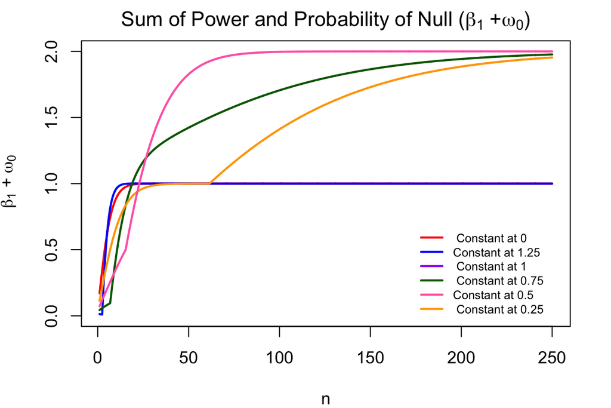

```r
par(mfrow=c(1,1))
par(mar=c(4,4,2,2))

plot(n, prob.null.sg(n, null.delta1,
                  theta=0)+prob.alt.sg(n, null.delta1,
                  theta=1),
     type="l",
     col="red",
     lwd=2,
     ylim=c(0,2),
     ylab=TeX(r'( $\beta_1$ + $\omega_0$)'),
     main= TeX(r'(Sum of Power and Probability of Null ($\beta_1$ +$\omega_0$))'))
lines(n, prob.null.sg(n, null.delta2,
                  theta=0)+prob.alt.sg(n, null.delta2,
                  theta=1),
      col="blue",
      lwd=2)
# lines(n, prob.null.sg(n, null.delta3,
#                   theta=0),
#       col="purple",
#       lwd=2)
lines(n, prob.null.sg(n, null.delta4,
                  theta=0)+prob.alt.sg(n, null.delta4,
                  theta=1),
      col="darkgreen",
      lwd=2)
lines(n, prob.null.sg(n, null.delta5,
                  theta=0)+prob.alt.sg(n, null.delta5,
                  theta=1),
      col="orange",
      lwd=2)
lines(n, prob.null.sg(n, null.delta0,
                  theta=0)+prob.alt.sg(n, null.delta0,
                  theta=1),
      col="hotpink",
      lwd=2)
legend(172, 0.7,
       col=c("red",
             "blue",
             "purple",
             "darkgreen",
             "hotpink",
             "orange"),
       box.lty=0,
       lty=c(1,
             1,
             1,
             1,
             1,
             1,
             2,
             2,
             2,
             2,
             2,
             2),
       cex=0.7,
       lwd=2,
       legend=c(TeX(r'( Constant at 0)'),
                TeX(r'(Constant at 1.25)'),
                 TeX(r'( Constant at 1)'),
                 TeX(r'( Constant at 0.75)'),
                 TeX(r'(Constant at 0.5)'),
                 TeX(r'( Constant at 0.25)')))
```

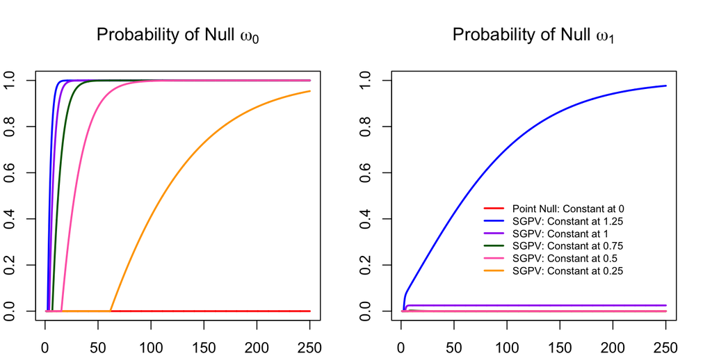

```r
par(mfrow=c(1,2))
par(mar=c(2,2,4,2))

plot(n, prob.null.sg(n, null.delta1,
                  theta=0),
     type="l",
     col="red",
     lwd=2,
     ylim=c(0,1),
     ylab="",
     main= TeX(r'(Probability of Null $\omega_0$)'))
lines(n, prob.null.sg(n, null.delta2,
                  theta=0),
      col="blue",
      lwd=2)
lines(n, prob.null.sg(n, null.delta3,
                  theta=0),
      col="purple",
      lwd=2)
lines(n, prob.null.sg(n, null.delta4,
                  theta=0),
      col="darkgreen",
      lwd=2)
lines(n, prob.null.sg(n, null.delta5,
                  theta=0),
      col="orange",
      lwd=2)
lines(n, prob.null.sg(n, null.delta0,
                  theta=0),
      col="hotpink",
      lwd=2)

plot(n, prob.null.sg(n, null.delta1,
                  theta=1),
     type="l",
     col="red",
     lwd=2,
     ylim=c(0,1),
     ylab="",
     main=TeX(r'(Probability of Null $\omega_1$)'))
lines(n, prob.null.sg(n, null.delta2,
                  theta=1),
      col="blue",
      lwd=2)
lines(n, prob.null.sg(n, null.delta3,
                  theta=1),
      col="purple",
      lwd=2)
lines(n, prob.null.sg(n, null.delta4,
                  theta=1),
      col="darkgreen",
      lwd=2)
lines(n, prob.null.sg(n, null.delta5,
                  theta=1),
      col="orange",
      lwd=2)
lines(n, prob.null.sg(n, null.delta0,
                  theta=1),
      col="hotpink",
      lwd=2)
legend(70, 0.5,
       col=c("red",
             "blue",
             "purple",
             "darkgreen",
             "hotpink",
             "orange"),
       box.lty=0,
       lty=c(1,
             1,
             1,
             1,
             1,
             1),
       cex=0.7,
       lwd=2,
       legend=c("Point Null: Constant at 0",
                "SGPV: Constant at 1.25",
                "SGPV: Constant at 1",
                "SGPV: Constant at 0.75",
                "SGPV: Constant at 0.5",
                "SGPV: Constant at 0.25"))
```

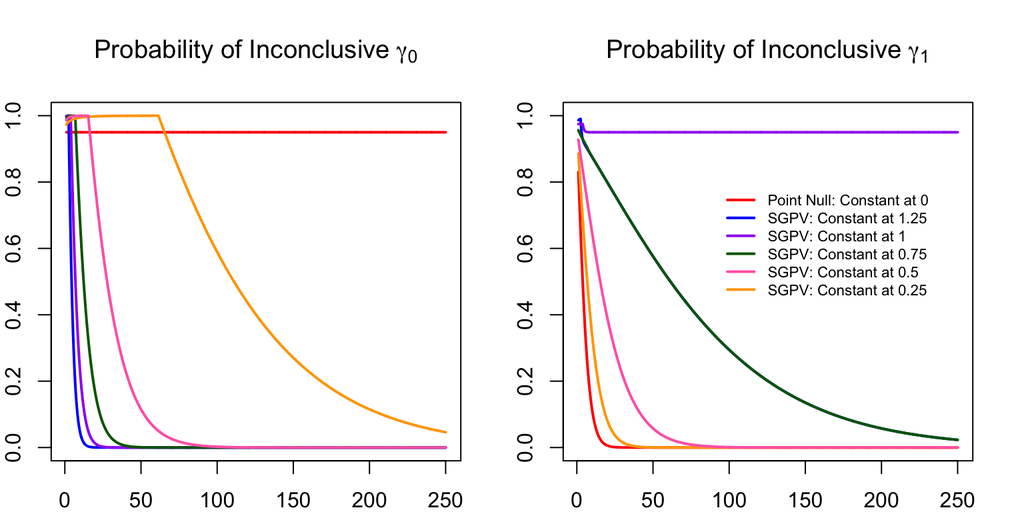

```r
par(mfrow=c(1,2))
par(mar=c(2,2,4,2))

plot(n,prob.incon.sg(n, null.delta1,
                  theta=0),
     type="l",
     col="red",
     lwd=2,
     ylim=c(0,1),
     ylab="",
     main=TeX(r'(Probability of Inconclusive $\gamma_0$)'))
lines(n,prob.incon.sg(n, null.delta2,
                  theta=0),
      col="blue",
      lwd=2)
lines(n,prob.incon.sg(n, null.delta3,
                  theta=0),
      col="purple",
      lwd=2)
lines(n,prob.incon.sg(n, null.delta4,
                  theta=0),
      col="darkgreen",
      lwd=2)
lines(n,prob.incon.sg(n, null.delta5,
                  theta=0),
      col="orange",
      lwd=2)
lines(n,prob.incon.sg(n, null.delta0,
                  theta=0),
      col="hotpink",
      lwd=2)

plot(n,prob.incon.sg(n, null.delta1,
                  theta=1),
     type="l",
     col="red",
     lwd=2,
     ylim=c(0,1),
     ylab="",
     main=TeX(r'(Probability of Inconclusive $\gamma_1$)'))
lines(n,prob.incon.sg(n, null.delta2,
                  theta=1),
      col="blue",
      lwd=2)
lines(n,prob.incon.sg(n, null.delta3,
                  theta=1),
      col="purple",
      lwd=2)
lines(n,prob.incon.sg(n, null.delta4,
                  theta=1),
      col="darkgreen",
      lwd=2)
lines(n,prob.incon.sg(n, null.delta5,
                  theta=1),
      col="orange",
      lwd=2)
lines(n,prob.incon.sg(n, null.delta0,
                  theta=1),
      col="hotpink",
      lwd=2)
legend(90, 0.8,
       col=c("red",
             "blue",
             "purple",
             "darkgreen",
             "hotpink",
             "orange"),
       box.lty=0,
       lty=c(1,
             1,
             1,
             1,
             1,
             1),
       cex=0.7,
       lwd=2,
       legend=c("Point Null: Constant at 0",
                "SGPV: Constant at 1.25",
                "SGPV: Constant at 1",
                "SGPV: Constant at 0.75",
                "SGPV: Constant at 0.5",
                "SGPV: Constant at 0.25"))
```

## 2.5 SGPV Variable Selection Vignettes

- [Linear ProSGPV](https://cran.r-project.org/web/packages/ProSGPV/vignettes/linear-vignette.html)
- [GLM and Cox ProSGPV](https://cran.r-project.org/web/packages/ProSGPV/vignettes/glm-cox-vignette.html)